# Food_Data

# Introduction

Group members:

Alexis TARIS

Tom TREMEREL

Aashita Gloria NOAH

Saanika MAMORIA

Helene QU

Published on RPub: https://rpubs.com/aashitax/1295523

In this presentation, we will analyze the relationship between countries and their cuisine preferences using Correspondence Analysis (CA) on the dataset provided.

📂 **Dataset: “World’s Favourite Cuisines”**

Contains responses from **24 countries**, across **34 international cuisines**.

- Each data point represents the number of people who expressed a preference for a specific cuisine in a given country.
- The data captures real-world culinary trends and global taste diversity.

🎯 **Business Objective:**

- Analyze whether a relationship exists between countries and their cuisine preferences.
- Identify groups of countries with similar culinary tastes to uncover regional and cultural patterns

# Data Loading

We begin by loading the dataset and cleaning it up:

```r
library(ca)
library(dplyr)
library(FactoMineR)
library(FactoMineR)
library(factoextra)
cuisine <- read.delim("Cusine-pref-raw.txt", header=T, na.strings = "", sep="\t", dec=".")
row.names(cuisine) <- cuisine$X
cuisine <- cuisine[,-1]
```

# Descriptive Statistics

We run some basic descriptive statistics to check the total number of cuisines, countries, and Top 5 most preferred Cuisines globally

```r
# Number of cuisines and countries
num_cuisines <- nrow(cuisine)
num_countries <- ncol(cuisine)

cat("Number of Cuisines:", num_cuisines, "\n")
```

```
Number of Cuisines: 34
```

```r
cat("Number of Countries:", num_countries, "\n")
```

```
Number of Countries: 24
```

```r
# Total preference count per cuisine
cuisine_totals <- rowSums(cuisine)
cuisine_totals <- sort(cuisine_totals, decreasing = TRUE)

# Top 5 most preferred cuisines globally
top5_cuisines <- head(cuisine_totals, 5)
top5_cuisines
```

```
Italian  Chinese  Mexican     Thai   French
   21929    20507    19609    18110    18021
```

```r
library(knitr)
kable(as.data.frame(top5_cuisines), col.names = c("Cuisine", "Total Count"), caption = "Top 5 Most Preferred Cuisines Globally")
```

Top 5 Most Preferred Cuisines Globally

| Cuisine | Total Count |
| --- | --- |
| Italian | 21929 |
| Chinese | 20507 |
| Mexican | 19609 |
| Thai | 18110 |
| French | 18021 |

# Per-Cuisine Summary Statistics

```r
cuisine_stats <- data.frame(
  Mean = round(rowMeans(cuisine), 2),
  Median = apply(cuisine, 1, median),
  Min = apply(cuisine, 1, min),
  Max = apply(cuisine, 1, max),
  SD = apply(cuisine, 1, sd)
)

kable(head(cuisine_stats, 10),
      caption = "Summary Statistics for First 10 Cuisines")
```

Summary Statistics for First 10 Cuisines

|  | Mean | Median | Min | Max | SD |
| --- | --- | --- | --- | --- | --- |
| Spanish | 734.75 | 687.5 | 369 | 1428 | 273.2920 |
| British | 553.38 | 521.5 | 200 | 1603 | 281.8474 |
| French | 750.88 | 721.0 | 471 | 1265 | 182.0058 |
| German | 582.21 | 524.5 | 351 | 1775 | 287.1356 |
| Italian | 913.71 | 879.5 | 598 | 1816 | 271.4011 |
| Danish | 434.42 | 406.5 | 140 | 856 | 172.6174 |
| Norwegian | 388.58 | 401.0 | 170 | 673 | 118.7075 |
| Finnish | 320.62 | 338.0 | 131 | 530 | 102.2511 |
| Swedish | 470.08 | 453.0 | 180 | 926 | 188.2962 |
| Greek | 610.79 | 557.0 | 220 | 1612 | 321.6810 |

# Per-Country Summary Statistics

```r
country_stats <- data.frame(
  Mean = round(colMeans(cuisine), 2),
  Median = apply(cuisine, 2, median),
  Min = apply(cuisine, 2, min),
  Max = apply(cuisine, 2, max),
  SD = apply(cuisine, 2, sd)
)

kable(head(country_stats, 10),
      caption = "Summary Statistics for First 10 Countries")
```

Summary Statistics for First 10 Countries

|  | Mean | Median | Min | Max | SD |
| --- | --- | --- | --- | --- | --- |
| Australia | 644.35 | 704.0 | 51 | 918 | 185.6275 |
| China | 470.00 | 441.0 | 264 | 963 | 165.0315 |
| Hong.Kong | 611.41 | 608.5 | 286 | 951 | 207.2495 |
| Indonesia | 493.38 | 481.0 | 236 | 993 | 174.0707 |
| Japan | 389.71 | 330.0 | 110 | 880 | 222.2132 |
| Malaysia | 552.79 | 542.0 | 261 | 973 | 185.4720 |
| Philippines | 642.59 | 606.0 | 285 | 988 | 164.1572 |
| Taiwan | 594.21 | 569.5 | 342 | 995 | 169.1327 |
| Thailand | 465.91 | 438.5 | 214 | 1000 | 213.6809 |
| Vietnam | 525.38 | 480.0 | 263 | 971 | 181.3604 |

# Bar Plot – Top 10 Most Preferred Cuisines Globally

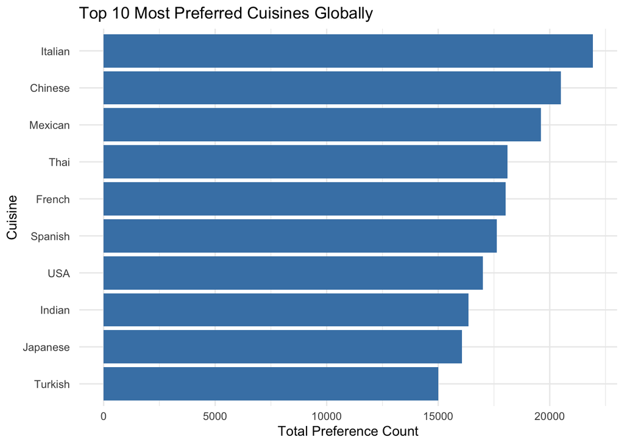

```r
library(ggplot2)

# Recalculate cuisine totals and sort
cuisine_totals <- rowSums(cuisine)
cuisine_totals_sorted <- sort(cuisine_totals, decreasing = TRUE)

# Create data frame for top 10
top10_df <- data.frame(
  Cuisine = names(cuisine_totals_sorted[1:10]),
  Total = cuisine_totals_sorted[1:10]
)

# Plot
ggplot(top10_df, aes(x = reorder(Cuisine, Total), y = Total)) +
  geom_bar(stat = "identity", fill = "steelblue") +
  coord_flip() +
  labs(title = "Top 10 Most Preferred Cuisines Globally",
       x = "Cuisine",
       y = "Total Preference Count") +
  theme_minimal()
```

# Chi-square Test of Independence

Next, we perform a Chi-Square test to check the relationship between countries and their cuisine preferences.

```r
cuisine <- as.table(as.matrix(cuisine))
chi <- chisq.test(cuisine)
chi
```

```
    Pearson's Chi-squared test

data:  cuisine
X-squared = 32158, df = 759, p-value < 2.2e-16
```

The p-value is extremely small (< 2.2e-16), indicating a highly significant relationship between countries and their cuisine preferences.

# Phi-squared Statistic

We calculate the Phi-squared statistic, which measures the strength of association between countries and their cuisine preferences.

```r
Phi2 <- chi$statistic / sum(cuisine)
Phi2
```

```
 X-squared
0.06847356
```

The Phi-squared statistic is 0.0685, indicating a weak association between countries and their cuisine preferences.

# Normalized Phi-squared

We normalize the Phi-squared value to understand the relative strength of the association.

```r
J <- ncol(cuisine)
I <- nrow(cuisine)
(I-1)*(J-1)
```

```
[1] 759
```

```r
max_Phi <- (min(I,J)-1)
Phi2/max_Phi
```

```
  X-squared
0.002977111
```

The normalized Phi-squared value is close to 0, suggesting a weak strength of association between countries and their cuisine preferences.

# Row Marginal Frequencies

We calculate the row and column proportions to better understand the distribution of preferences:

```r
cuisine<- as.table(as.matrix(cuisine))
F <- as.matrix(prop.table(cuisine))
Row.F <- prop.table(cuisine, margin=1)
round(addmargins(Row.F), 3)
```

```
               Australia  China Hong.Kong Indonesia  Japan Malaysia Philippines
Spanish            0.043  0.022     0.039     0.021  0.036    0.025       0.050
British            0.055  0.033     0.047     0.045  0.015    0.049       0.054
French             0.040  0.035     0.041     0.026  0.038    0.032       0.046
German             0.046  0.033     0.048     0.027  0.033    0.025       0.043
Italian            0.042  0.027     0.038     0.033  0.039    0.034       0.042
Danish             0.046  0.031     0.039     0.028  0.013    0.032       0.050
Norwegian          0.043  0.034     0.046     0.025  0.018    0.033       0.051
Finnish            0.049  0.040     0.051     0.031  0.018    0.034       0.062
Swedish            0.042  0.031     0.044     0.024  0.016    0.032       0.045
Greek              0.054  0.022     0.033     0.019  0.015    0.021       0.040
Turkish            0.048  0.032     0.031     0.044  0.026    0.039       0.041
Moroccan           0.004  0.029     0.033     0.033  0.013    0.038       0.043
Lebanese           0.060  0.026     0.026     0.027  0.011    0.036       0.034
Saudi Arabian      0.044  0.033     0.033     0.069  0.012    0.070       0.051
Emirati            0.045  0.030     0.029     0.055  0.014    0.052       0.053
Indian             0.046  0.016     0.030     0.031  0.039    0.043       0.034
Chinese            0.043  0.047     0.045     0.028  0.043    0.036       0.044
Thai               0.048  0.025     0.047     0.029  0.027    0.050       0.043
Malaysian          0.061  0.033     0.054     0.053  0.020    0.077       0.052
Vietnamese         0.053  0.026     0.055     0.024  0.031    0.031       0.047
Singaporean        0.059  0.042     0.057     0.043  0.025    0.057       0.056
Hong Kong          0.049  0.049     0.067     0.034  0.037    0.038       0.057
Korean             0.046  0.036     0.055     0.044  0.045    0.045       0.061
Filipino           0.060  0.031     0.031     0.031  0.022    0.035       0.104
Indonesian         0.055  0.024     0.036     0.076  0.025    0.061       0.046
Taiwanese          0.046  0.049     0.069     0.031  0.050    0.037       0.053
Australian         0.073  0.033     0.047     0.034  0.022    0.043       0.060
Japanese           0.039  0.036     0.047     0.037  0.027    0.036       0.037
USA                0.032  0.029     0.055     0.045  0.039    0.041       0.032
Mexican            0.040  0.037     0.045     0.037  0.033    0.039       0.037
Caribbean          0.037  0.041     0.052     0.036  0.025    0.049       0.038
Argentinian        0.057  0.058     0.036     0.034  0.021    0.034       0.045
Brazilian          0.052  0.044     0.043     0.038  0.030    0.038       0.038
Peruvian           0.046  0.059     0.052     0.044  0.027    0.032       0.033
Sum                1.603  1.172     1.501     1.239  0.904    1.376       1.623
               Taiwan Thailand Vietnam  India Singapore  Italy  Spain    USA
Spanish         0.036    0.023   0.026  0.038     0.039  0.049  0.056  0.053
British         0.039    0.034   0.046  0.060     0.058  0.024  0.020  0.044
French          0.041    0.035   0.040  0.045     0.044  0.033  0.039  0.045
```

[output cut: 89 more lines]

```
Singaporean      0.042  0.019  1.000
Hong Kong        0.040  0.019  1.000
Korean           0.041  0.022  1.000
Filipino         0.041  0.031  1.000
Indonesian       0.041  0.024  1.000
Taiwanese        0.042  0.017  1.000
Australian       0.041  0.024  1.000
Japanese         0.045  0.028  1.000
USA              0.040  0.029  1.000
Mexican          0.035  0.031  1.000
Caribbean        0.034  0.029  1.000
Argentinian      0.033  0.029  1.000
Brazilian        0.036  0.027  1.000
Peruvian         0.038  0.026  1.000
Sum              1.367  0.976 34.000
```

```r
Row.F <- as.data.frame(Row.F)
```

# Column Marginal Frequencies

We also calculate the column proportions to see the distribution of cuisines across countries

```r
Col.F <- prop.table(cuisine, margin=2)
round(addmargins(Col.F), 3)
```

```
               Australia  China Hong.Kong Indonesia  Japan Malaysia Philippines
Spanish            0.034  0.024     0.033     0.022  0.048    0.023       0.040
British            0.033  0.027     0.030     0.035  0.015    0.035       0.033
French             0.033  0.040     0.036     0.028  0.051    0.031       0.038
German             0.029  0.029     0.032     0.023  0.035    0.019       0.028
Italian            0.042  0.037     0.040     0.043  0.064    0.039       0.042
Danish             0.022  0.020     0.020     0.017  0.011    0.018       0.024
Norwegian          0.018  0.020     0.021     0.014  0.013    0.017       0.022
Finnish            0.017  0.019     0.019     0.014  0.011    0.014       0.022
Swedish            0.022  0.022     0.024     0.016  0.014    0.019       0.023
Greek              0.036  0.020     0.023     0.016  0.017    0.017       0.027
Turkish            0.033  0.030     0.022     0.040  0.029    0.031       0.028
Moroccan           0.002  0.022     0.019     0.024  0.012    0.024       0.023
Lebanese           0.033  0.020     0.015     0.020  0.010    0.023       0.019
Saudi Arabian      0.019  0.020     0.015     0.039  0.008    0.035       0.022
Emirati            0.020  0.018     0.014     0.032  0.011    0.027       0.024
Indian             0.034  0.017     0.024     0.030  0.048    0.037       0.026
Chinese            0.040  0.060     0.045     0.035  0.066    0.039       0.041
Thai               0.040  0.028     0.041     0.031  0.036    0.049       0.035
Malaysian          0.035  0.026     0.033     0.040  0.019    0.052       0.030
Vietnamese         0.035  0.023     0.038     0.021  0.033    0.024       0.031
Singaporean        0.035  0.034     0.036     0.034  0.025    0.039       0.034
Hong Kong          0.032  0.043     0.046     0.029  0.040    0.029       0.037
Korean             0.031  0.033     0.038     0.038  0.050    0.035       0.041
Filipino           0.026  0.018     0.014     0.018  0.016    0.018       0.045
Indonesian         0.033  0.020     0.023     0.059  0.024    0.043       0.028
Taiwanese          0.027  0.041     0.043     0.024  0.050    0.026       0.032
Australian         0.041  0.026     0.029     0.025  0.021    0.029       0.035
Japanese           0.029  0.036     0.036     0.035  0.032    0.030       0.027
USA                0.025  0.031     0.045     0.046  0.050    0.037       0.025
Mexican            0.036  0.046     0.042     0.043  0.048    0.041       0.033
Caribbean          0.023  0.034     0.033     0.029  0.025    0.035       0.023
Argentinian        0.035  0.049     0.024     0.027  0.022    0.025       0.028
Brazilian          0.031  0.036     0.027     0.029  0.029    0.026       0.023
Peruvian           0.018  0.032     0.022     0.023  0.017    0.014       0.013
Sum                1.000  1.000     1.000     1.000  1.000    1.000       1.000
               Taiwan Thailand Vietnam  India Singapore  Italy  Spain    USA
Spanish         0.032    0.025   0.025  0.031     0.030  0.056  0.062  0.043
British         0.026    0.028   0.035  0.036     0.034  0.021  0.017  0.027
French          0.036    0.040   0.041  0.037     0.035  0.038  0.045  0.038
```

[output cut: 89 more lines]

```
Singaporean      0.029  0.019  0.659
Hong Kong        0.031  0.020  0.722
Korean           0.032  0.023  0.756
Filipino         0.021  0.022  0.477
Indonesian       0.028  0.023  0.660
Taiwanese        0.029  0.017  0.677
Australian       0.027  0.022  0.631
Japanese         0.039  0.033  0.827
USA              0.036  0.037  0.882
Mexican          0.037  0.046  1.015
Caribbean        0.025  0.029  0.684
Argentinian      0.024  0.029  0.695
Brazilian        0.025  0.026  0.669
Peruvian         0.017  0.016  0.446
Sum              1.000  1.000 24.000
```

```r
Col.F <- as.data.frame(Col.F)
```

This shows how the cuisines are distributed across different countries.

# Correspondence Analysis

We perform Correspondence Analysis (CA) to visualize the relationship between countries and cuisines.

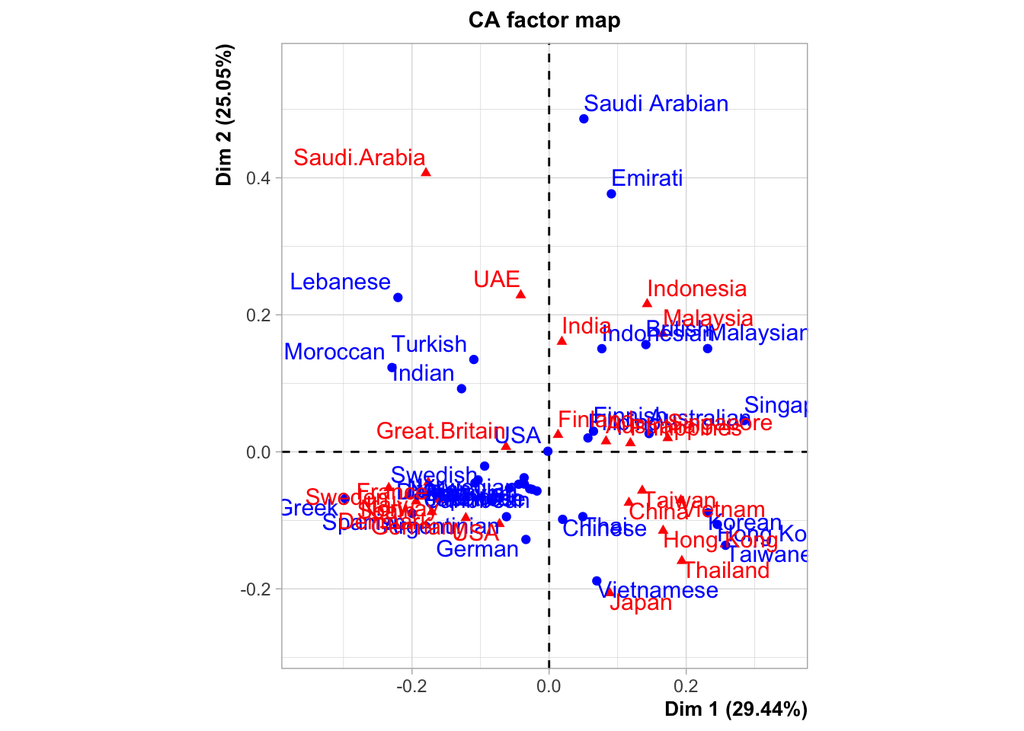

```r
results <- CA(cuisine)
```

```r
summary(results)
```

```
Call:
CA(X = cuisine)

The chi square of independence between the two variables is equal to 32158.4 (p-value =  0 ).

Eigenvalues
                       Dim.1   Dim.2   Dim.3   Dim.4   Dim.5   Dim.6   Dim.7
Variance               0.020   0.017   0.006   0.004   0.004   0.003   0.002
% of var.             29.441  25.046   9.444   6.154   5.540   4.410   3.602
Cumulative % of var.  29.441  54.487  63.931  70.085  75.625  80.035  83.637
                       Dim.8   Dim.9  Dim.10  Dim.11  Dim.12  Dim.13  Dim.14
Variance               0.002   0.002   0.001   0.001   0.001   0.001   0.001
% of var.              2.997   2.263   2.148   1.856   1.498   1.202   1.038
Cumulative % of var.  86.635  88.898  91.046  92.903  94.401  95.603  96.641
                      Dim.15  Dim.16  Dim.17  Dim.18  Dim.19  Dim.20  Dim.21
Variance               0.001   0.001   0.000   0.000   0.000   0.000   0.000
% of var.              0.884   0.798   0.571   0.364   0.285   0.229   0.104
Cumulative % of var.  97.525  98.323  98.893  99.257  99.542  99.772  99.875
                      Dim.22  Dim.23
Variance               0.000   0.000
% of var.              0.093   0.031
Cumulative % of var.  99.969 100.000

Rows (the 10 first)
                 Iner*1000    Dim.1    ctr   cos2    Dim.2    ctr   cos2
Spanish        |     2.406 | -0.200  7.433  0.623 | -0.090  1.764  0.126 |
British        |     2.838 |  0.141  2.795  0.199 |  0.157  4.041  0.244 |
French         |     0.651 | -0.058  0.636  0.197 | -0.053  0.628  0.165 |
German         |     1.711 | -0.034  0.169  0.020 | -0.128  2.838  0.284 |
Italian        |     0.978 | -0.104  2.487  0.513 | -0.041  0.458  0.080 |
Danish         |     2.579 | -0.108  1.291  0.101 | -0.045  0.267  0.018 |
Norwegian      |     1.166 | -0.036  0.131  0.023 | -0.038  0.165  0.024 |
Finnish        |     0.685 |  0.065  0.340  0.100 |  0.030  0.086  0.022 |
Swedish        |     1.800 | -0.094  1.054  0.118 | -0.021  0.061  0.006 |
Greek          |     3.506 | -0.298 13.714  0.789 | -0.068  0.851  0.042 |
                Dim.3    ctr   cos2
Spanish         0.029  0.484  0.013 |
British        -0.109  5.218  0.119 |
French          0.026  0.408  0.040 |
German          0.011  0.054  0.002 |
```

[output cut: 15 more lines]

```
Philippines    |     2.820 |  0.119  3.246  0.232 |  0.013  0.044  0.003 |
Taiwan         |     1.532 |  0.136  3.939  0.518 | -0.057  0.803  0.090 |
Thailand       |     3.192 |  0.194  6.271  0.396 | -0.159  4.986  0.268 |
Vietnam        |     2.587 |  0.192  6.968  0.543 | -0.071  1.105  0.073 |
                Dim.3    ctr   cos2
Australia      -0.067  3.192  0.087 |
China           0.155 12.605  0.305 |
Hong.Kong       0.013  0.118  0.003 |
Indonesia       0.076  3.228  0.053 |
Japan           0.138  8.281  0.141 |
Malaysia       -0.013  0.108  0.002 |
Philippines    -0.057  2.303  0.053 |
Taiwan          0.040  1.044  0.044 |
Thailand        0.015  0.121  0.002 |
Vietnam        -0.045  1.176  0.029 |
```

```r
results$col
```

```
$coord
                    Dim 1        Dim 2       Dim 3        Dim 4       Dim 5
Australia      0.08302005  0.015458427 -0.06651434  0.048309050 -0.13749088
China          0.11636375 -0.074221549  0.15477191  0.036122312 -0.06783837
Hong.Kong      0.16633782 -0.115040602  0.01312089 -0.034251859  0.03487409
Indonesia      0.14300827  0.215668276  0.07644340 -0.091139659 -0.02254778
Japan          0.08839067 -0.206139310  0.13776466 -0.074998055  0.12097466
Malaysia       0.16597221  0.172453324 -0.01323118 -0.104430896 -0.02000844
Philippines    0.11859589  0.012681574 -0.05657836  0.140223977 -0.06519760
Taiwan         0.13586556 -0.056572381  0.03962091  0.027554751  0.01156622
Thailand       0.19360528 -0.159222967  0.01521012  0.008073417  0.10828190
Vietnam        0.19217897 -0.070595302 -0.04472258  0.069616494  0.08000705
India          0.01859268  0.160750801 -0.02082196  0.019764236  0.02358728
Singapore      0.17301652  0.020108128 -0.06858183 -0.031258811 -0.02764422
Italy         -0.20517073 -0.063331621  0.13022158 -0.019302881 -0.07970447
Spain         -0.19406168 -0.072168422  0.18260571 -0.012604036 -0.06944199
USA           -0.07242346 -0.105271191  0.01557629 -0.006611319  0.02710857
UAE           -0.04138612  0.228636926  0.02420461  0.076638085  0.03735896
Saudi.Arabia  -0.17968909  0.406887194  0.07586517  0.031552953  0.09787759
Great.Britain -0.06293473  0.007351443 -0.08739636 -0.135649102 -0.04635864
Germany       -0.12155128 -0.096561187  0.01088307  0.038673434 -0.03989288
France        -0.17626602 -0.044630256  0.04232722  0.011030364  0.03780012
Denmark       -0.17115684 -0.087737443 -0.11416890 -0.054505232  0.04752876
Sweden        -0.23389641 -0.052763176 -0.13582623  0.027205028  0.05911801
Finland        0.01304349  0.024829005 -0.02092509  0.020400905  0.02122852
Norway        -0.16092400 -0.069835342 -0.12285816  0.036780175  0.01071321

$contrib
                    Dim 1       Dim 2      Dim 3       Dim 4       Dim 5
Australia      1.59484529  0.06499741  3.1915596  2.58339692 23.24682875
China          2.28539903  1.09294812 12.6046493  1.05355995  4.12801106
Hong.Kong      6.07497542  3.41568449  0.1178444  1.23228854  1.41916073
Indonesia      3.62355346  9.68718987  3.2278415  7.04058479  0.47872205
Japan          1.09339871  6.99037159  8.2805885  3.76571363 10.88473648
Malaysia       5.46843332  6.93982020  0.1083452 10.35694687  0.42235933
Philippines    3.24564352  0.04362352  2.3029369 21.70639279  5.21300464
Taiwan         3.93898613  0.80276332  1.0443221  0.77506879  0.15170932
Thailand       6.27143323  4.98605160  0.1206751  0.05217096 10.42575531
Vietnam        6.96812514  1.10527094  1.1764618  4.37431545  6.41836140
India          0.07957391  6.99207353  0.3111357  0.43015839  0.68062179
```

[output cut: 32 more lines]

```
Saudi.Arabia  0.146093177 0.749090979 0.026041821 0.0045047069 0.043346403
Great.Britain 0.087721627 0.001196936 0.169165814 0.4075301567 0.047597836
Germany       0.308266011 0.194541276 0.002471207 0.0312055645 0.033204532
France        0.562139978 0.036038446 0.032415064 0.0022013392 0.025851972
Denmark       0.302131137 0.079392030 0.134431978 0.0306396184 0.023298065
Sweden        0.537791761 0.027367107 0.181356998 0.0072755422 0.034356323
Finland       0.038606939 0.139893235 0.099360281 0.0944445590 0.102262756
Norway        0.352352364 0.066356902 0.205373109 0.0184061586 0.001561618

$inertia
 [1] 0.0023796267 0.0026731030 0.0023193980 0.0039337967 0.0037852258
 [6] 0.0032774015 0.0028197182 0.0015315030 0.0031923409 0.0025867910
[11] 0.0018858648 0.0022105590 0.0026525604 0.0029742252 0.0015067366
[16] 0.0028583893 0.0074414265 0.0032302923 0.0035204908 0.0022167149
[21] 0.0033158438 0.0038832314 0.0001760004 0.0021023171
```

The CA results provide us with information about how countries and cuisines relate in a low-dimensional space.

On this map we can already make some conclusions about the relationship between the regions and the cuisines, with Occidental, Oriental and Asian region.

# Scree plot analysis

This visualization presents the percentage of variance explained by each dimension in our culinary preferences analysis. The scree plot is a critical tool for determining how many dimensions we should retain for meaningful interpretation. Each bar represents one dimension, with its height indicating the proportion of total variance explained by that dimension.

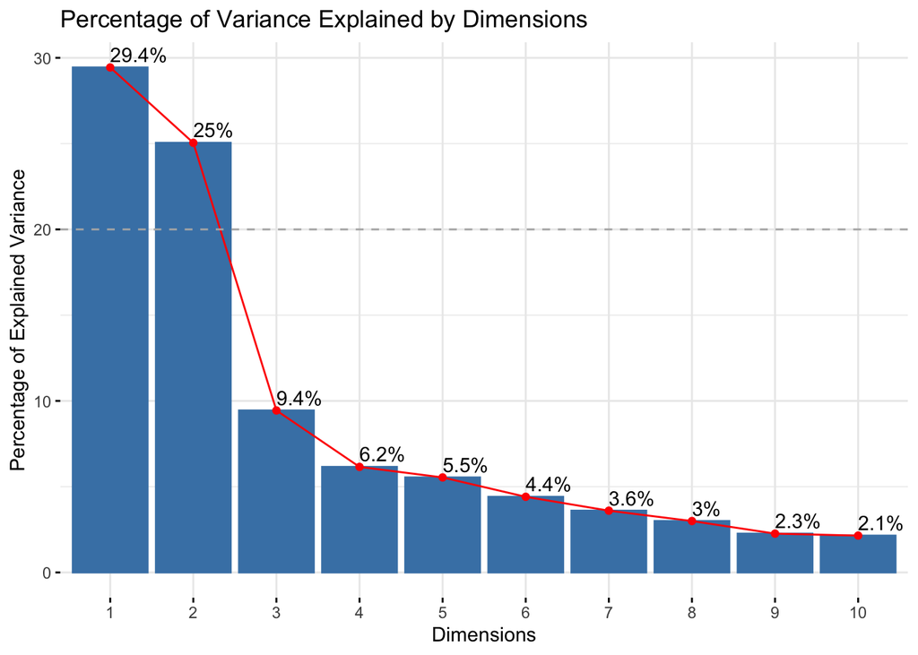

```r
# Sccreeplot with fviz_screeplot
fviz_screeplot(results,
               addlabels = TRUE,  # Add percentage values
               ncp = 10,          # Display the first 10 dimensions
               choice = "variance",
               main = "Percentage of Variance Explained by Dimensions",
               xlab = "Dimensions",
               ylab = "Percentage of Explained Variance",
               barfill = "steelblue",
               barcolor = "steelblue",
               linecolor = "red") +
  geom_hline(yintercept = 1/(ncol(results$row$coord))*100,
             linetype = "dashed",
             color = "gray70")
```

# Elbow method

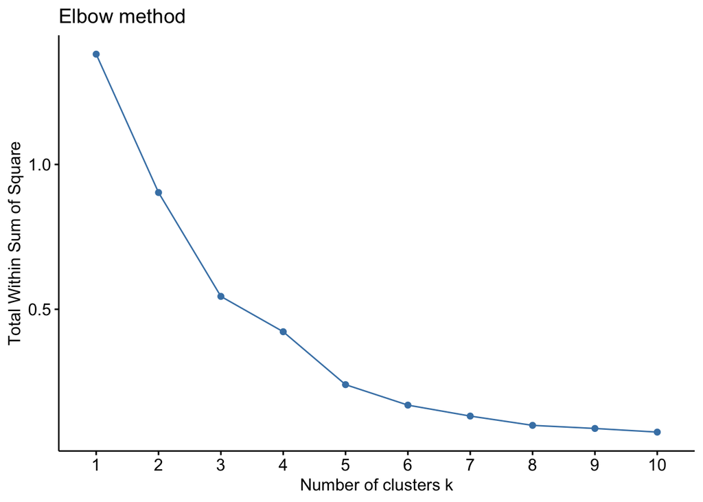

```r
# Récupérer les coordonnées des individus (limité aux 2 premières dimensions)
ind_coordinates <- results$row$coord[, 1:2]

# Méthode du coude
fviz_nbclust(ind_coordinates, kmeans, method = "wss") +
  labs(title = "Elbow method")
```

## K-means Clustering of Culinary Preferences

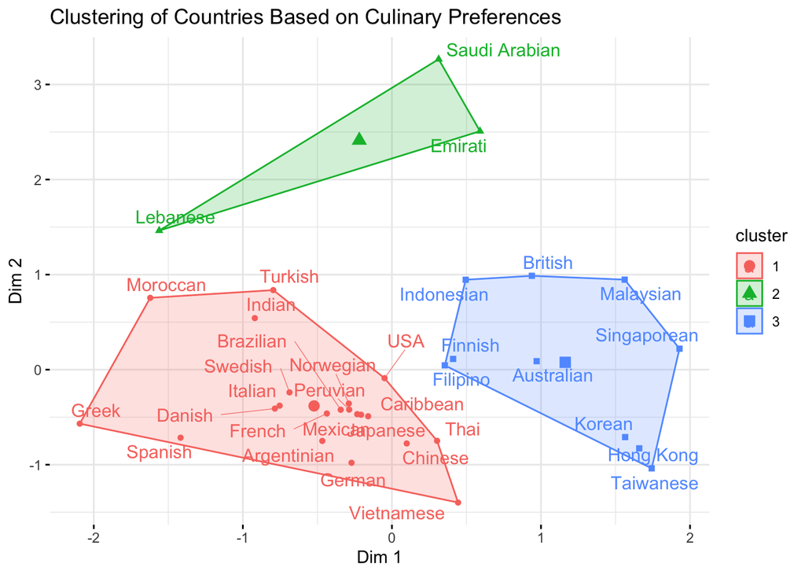

```r
# Clustering avec K-means
set.seed(123)  # Pour la reproductibilité
k <- 3  # Choisir le nombre de clusters
kmeans_result <- kmeans(ind_coordinates, centers = k)

# Visualisation des clusters avec étiquettes forcées
p <- fviz_cluster(kmeans_result,
                  data = ind_coordinates,
                  geom = c("point", "text"),
                  stand = TRUE,
                  ellipse.type = "convex",
                  repel = TRUE,
                  ggtheme = theme_minimal(),
                  main = "Clustering of Countries Based on Culinary Preferences")

# Afficher le graphique
print(p)
```

# Clustering sizes

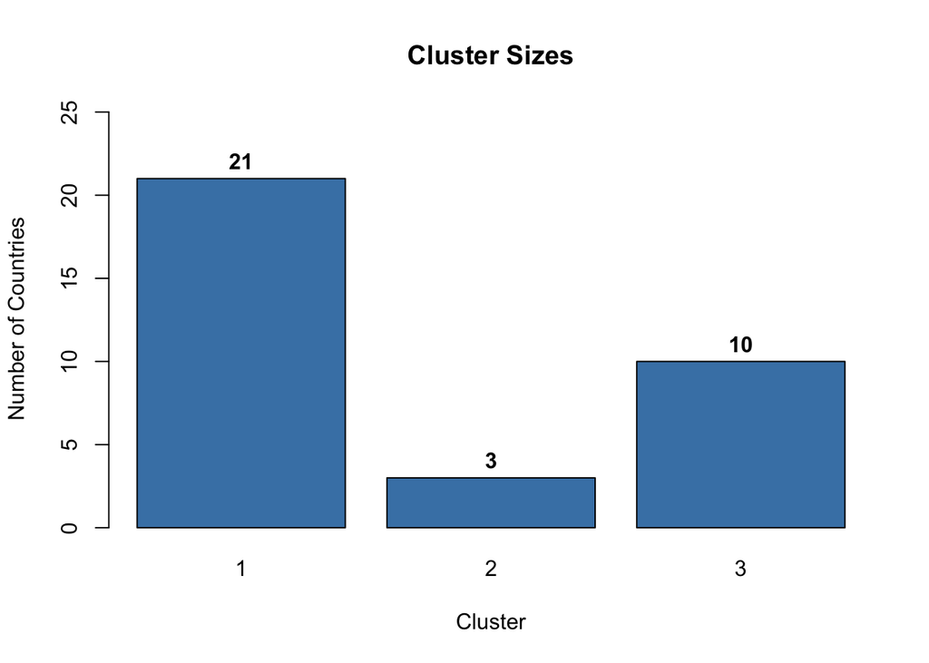

```r
# Cluster sizes
cluster_sizes <- table(kmeans_result$cluster)
bp <- barplot(cluster_sizes,
              main = "Cluster Sizes",
              xlab = "Cluster",
              ylab = "Number of Countries",
              col = "steelblue",
              ylim = c(0, max(cluster_sizes) * 1.2)) # Increase y-axis limit to make room for labels

# Add text labels on top of each bar showing count
text(x = bp,
     y = cluster_sizes + max(cluster_sizes) * 0.05, # Position labels slightly above bars
     labels = cluster_sizes,
     col = "black",
     font = 2)
```

# Dispersion within Clusters

Clusters with lower distances indicate groups of countries sharing very similar culinary preferences, while higher distances suggest more diverse traditions within that cluster. This visualization helps us evaluate the internal cohesion of each culinary pattern and understand which clusters represent more uniform versus more varied preference groups.

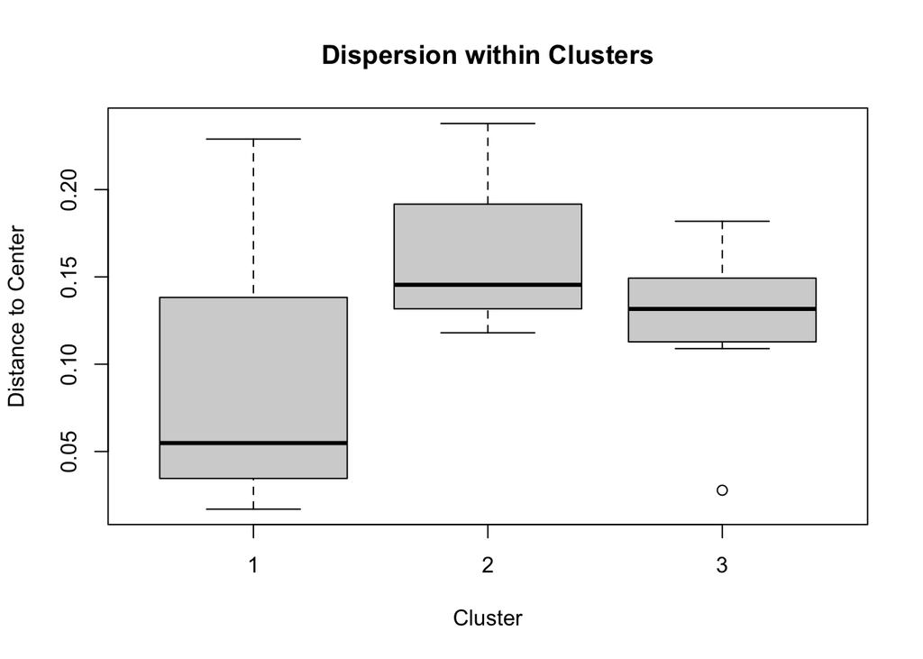

```r
# Distance des points au centre de leur cluster
within_cluster_distances <- rep(0, nrow(ind_coordinates))
for(i in 1:nrow(ind_coordinates)) {
  cluster_i <- kmeans_result$cluster[i]
  center_i <- kmeans_result$centers[cluster_i,]
  within_cluster_distances[i] <- dist(rbind(ind_coordinates[i,], center_i))
}

boxplot(within_cluster_distances ~ kmeans_result$cluster,
        main = "Dispersion within Clusters",
        xlab = "Cluster",
        ylab = "Distance to Center")
```

# Conclusion

This analysis highlights culinary preferences across 24 countries and 34 cuisines, using a combination of descriptive statistics, independence tests, and exploratory methods. Italian, Chinese, and Mexican cuisines emerge as the most globally preferred.

The chi-square test reveals a statistically significant relationship between countries and cuisines, but with weak association strength (Phi² ≈ 0.068, normalized ≈ 0.003), reflecting high diversity in preferences both between and within countries.

Correspondence Analysis (CA) was then used to visualize these complex relationships, revealing clusters of countries and cuisines with similar profiles. Finally, clustering techniques helped identify coherent groups, illustrating regional or cultural similarities in food preferences.

In summary, culinary preferences are both globalized and culturally rooted, and the multidimensional approach used here provides valuable insights into global taste patterns.

# Business Insights and Recommendations:

Italian, Chinese, and Mexican cuisines are top global performers, making them ideal anchors for international menus. Quick Service Restaurants (QSRs), food delivery platforms, and international hotel chains can prioritize these cuisines in multicultural markets. Food brands may also focus on product development around these cuisines to maximize global appeal.

The low association strength (Phi² ≈ 0.068) indicates there is no universal food preference pattern, highlighting the need for personalized marketing strategies. This opens the door for hyper-localized recommendation systems and individualized promotions based on regional or demographic nuances. Companies should avoid generalizing taste preferences across continents.

Lastly, new brands or restaurants entering global markets can start with universally loved cuisines and then use these cluster-based insights to expand gradually into more culturally specific offerings. This phased approach ensures higher acceptance and more sustainable market penetration.